# Bank Marketing

M.Bonamichi

21 de julho de 2018

## Análises | Actionable Insights

O objetivo dessa análise é extrair insights, a partir dos dados coletados, para direcionar, orquestrar e coreografar as próximas campanhas, a partir dos padrões encontrados nos dados.

### Conhecendo os dados | Lendo os Dados & Tipos das Variáveis

Primeiro vamos importar o dataset, e conhecer os tipos das variáveis com as quais trabalharemos.

```r
df <- read.csv("bank-full.csv", sep = ";")
str(df)
```

```
## 'data.frame':    45211 obs. of  17 variables:
##  $ age      : int  58 44 33 47 33 35 28 42 58 43 ...
##  $ job      : Factor w/ 12 levels "admin.","blue-collar",..: 5 10 3 2 12 5 5 3 6 10 ...
##  $ marital  : Factor w/ 3 levels "divorced","married",..: 2 3 2 2 3 2 3 1 2 3 ...
##  $ education: Factor w/ 4 levels "primary","secondary",..: 3 2 2 4 4 3 3 3 1 2 ...
##  $ default  : Factor w/ 2 levels "no","yes": 1 1 1 1 1 1 1 2 1 1 ...
##  $ balance  : int  2143 29 2 1506 1 231 447 2 121 593 ...
##  $ housing  : Factor w/ 2 levels "no","yes": 2 2 2 2 1 2 2 2 2 2 ...
##  $ loan     : Factor w/ 2 levels "no","yes": 1 1 2 1 1 1 2 1 1 1 ...
##  $ contact  : Factor w/ 3 levels "cellular","telephone",..: 3 3 3 3 3 3 3 3 3 3 ...
##  $ day      : int  5 5 5 5 5 5 5 5 5 5 ...
##  $ month    : Factor w/ 12 levels "apr","aug","dec",..: 9 9 9 9 9 9 9 9 9 9 ...
##  $ duration : int  261 151 76 92 198 139 217 380 50 55 ...
##  $ campaign : int  1 1 1 1 1 1 1 1 1 1 ...
##  $ pdays    : int  -1 -1 -1 -1 -1 -1 -1 -1 -1 -1 ...
##  $ previous : int  0 0 0 0 0 0 0 0 0 0 ...
##  $ poutcome : Factor w/ 4 levels "failure","other",..: 4 4 4 4 4 4 4 4 4 4 ...
##  $ y        : Factor w/ 2 levels "no","yes": 1 1 1 1 1 1 1 1 1 1 ...
```

### Conhecendo os dados | Valores das Variáveis

Agora que conhecemos os tipos das variáveis, vamos conhecer suas distribuições, amplitude, mediana, quantidade etc.

```r
summary(df)
```

```
##       age                 job           marital          education
##  Min.   :18.00   blue-collar:9732   divorced: 5207   primary  : 6851
##  1st Qu.:33.00   management :9458   married :27214   secondary:23202
##  Median :39.00   technician :7597   single  :12790   tertiary :13301
##  Mean   :40.94   admin.     :5171                    unknown  : 1857
##  3rd Qu.:48.00   services   :4154
##  Max.   :95.00   retired    :2264
##                  (Other)    :6835
##  default        balance       housing      loan            contact
##  no :44396   Min.   : -8019   no :20081   no :37967   cellular :29285
##  yes:  815   1st Qu.:    72   yes:25130   yes: 7244   telephone: 2906
##              Median :   448                           unknown  :13020
##              Mean   :  1362
##              3rd Qu.:  1428
##              Max.   :102127
##
##       day            month          duration         campaign
##  Min.   : 1.00   may    :13766   Min.   :   0.0   Min.   : 1.000
##  1st Qu.: 8.00   jul    : 6895   1st Qu.: 103.0   1st Qu.: 1.000
##  Median :16.00   aug    : 6247   Median : 180.0   Median : 2.000
##  Mean   :15.81   jun    : 5341   Mean   : 258.2   Mean   : 2.764
##  3rd Qu.:21.00   nov    : 3970   3rd Qu.: 319.0   3rd Qu.: 3.000
##  Max.   :31.00   apr    : 2932   Max.   :4918.0   Max.   :63.000
##                  (Other): 6060
##      pdays          previous           poutcome       y
##  Min.   : -1.0   Min.   :  0.0000   failure: 4901   no :39922
##  1st Qu.: -1.0   1st Qu.:  0.0000   other  : 1840   yes: 5289
##  Median : -1.0   Median :  0.0000   success: 1511
##  Mean   : 40.2   Mean   :  0.5803   unknown:36959
##  3rd Qu.: -1.0   3rd Qu.:  0.0000
##  Max.   :871.0   Max.   :275.0000
##
```

## 1. Qual profissão tem mais tendência a fazer um empréstimo?

### De qual tipo?

Vamos começar nossa análise visualizando a distribuição das profissões que adquiriram crédito à habitação.

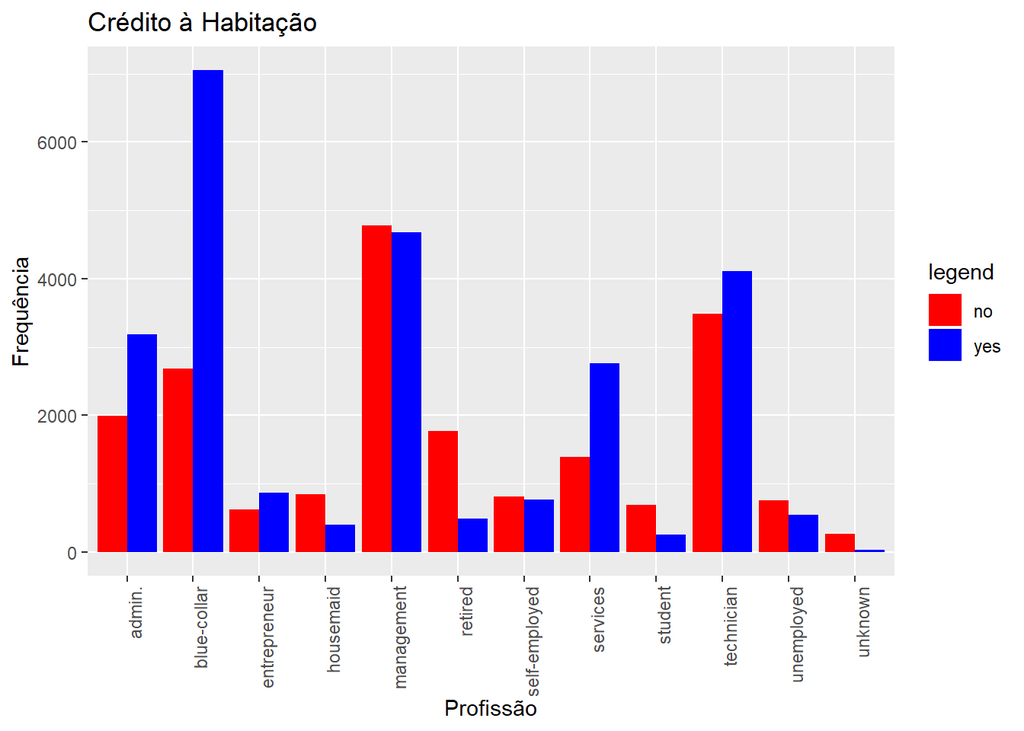

Agora que conhecemos a distribuição dos dados, podemos realizar uma análise confirmatória, e verificar quais profissões são mais inclinadas a adquirir crédito à habitação.

```
## [1] "technician"
## [1] "entrepreneur"
## [1] "blue-collar"
## [1] "admin."
## [1] "services"
```

Agora, vamos visualizar a distribuição das profissões que adquiriram crédito pessoal.

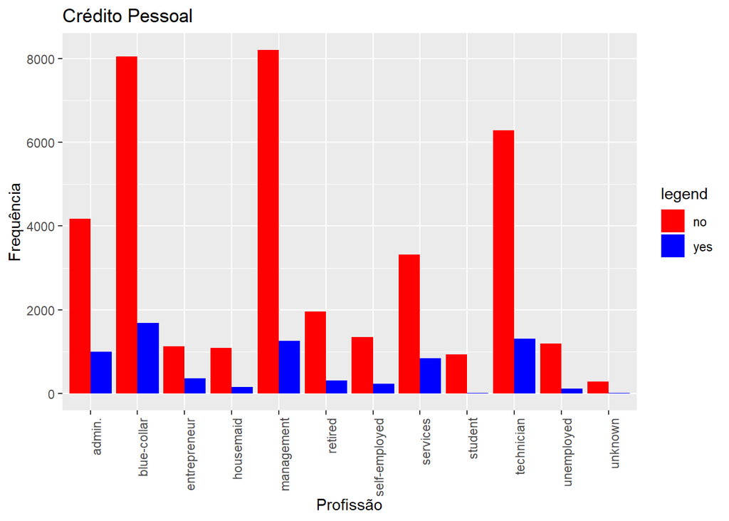

A distribuição dos dados já responde à nossa pergunta, e podemos afirmar, sem uma análise confirmatória, que créditos pessoais são adquiridos com muito menos frequência, por todas as profissões, de forma unânime.

## 1. Conclusão

É unânine que todas as profissões são muito pouco, ou nada, inclinadas a fazer empréstimos pessoais, mas as profissões technician, entrepreneur, blue-collar, admin. e services aquiescem positiva e satisfatoriamente a creditos à moradia.

## 2. Fazendo uma relação entre número de contatos e sucesso da campanha quais são os pontos relevantes a serem observados?

Vamos conhecer as variáveis relacionadas ao número de interações com o cliente.

```
##       contact           day            month          duration
##  cellular :29285   Min.   : 1.00   may    :13766   Min.   :   0.0
##  telephone: 2906   1st Qu.: 8.00   jul    : 6895   1st Qu.: 103.0
##  unknown  :13020   Median :16.00   aug    : 6247   Median : 180.0
##                    Mean   :15.81   jun    : 5341   Mean   : 258.2
##                    3rd Qu.:21.00   nov    : 3970   3rd Qu.: 319.0
##                    Max.   :31.00   apr    : 2932   Max.   :4918.0
##                                    (Other): 6060
##     campaign         previous           poutcome
##  Min.   : 1.000   Min.   :  0.0000   failure: 4901
##  1st Qu.: 1.000   1st Qu.:  0.0000   other  : 1840
##  Median : 2.000   Median :  0.0000   success: 1511
##  Mean   : 2.764   Mean   :  0.5803   unknown:36959
##  3rd Qu.: 3.000   3rd Qu.:  0.0000
##  Max.   :63.000   Max.   :275.0000
##
```

O número de contatos realizados antes da campanha é o dado mais curioso. Vamos analisá-lo.

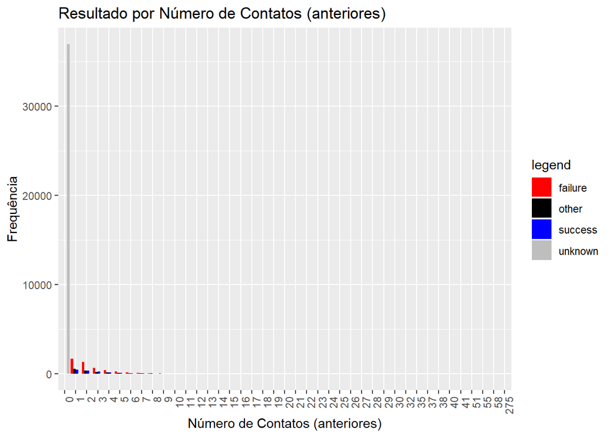

Os resultados de clientes que nunca foram contactados é sempre desconhecido, vamos remover esse dado da análise.

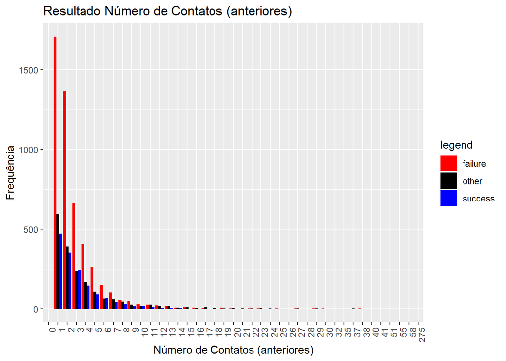

A distribuição dos dados não mostra uma diferença significativa, embora de grandezas diferentes o comportamento, o padrão entre elas é muito parecido, se não o mesmo.

A título de encontrarmos padrões que possam direcionar as próximas campanhas, vamos comparar os resultados positivos contra os negativos.

```
##       contact         month         duration         campaign
##  cellular :5914   may    :1923   Min.   :   1.0   Min.   : 1.00
##  telephone: 455   nov    : 938   1st Qu.: 116.0   1st Qu.: 1.00
##  unknown  :  43   apr    : 866   Median : 196.0   Median : 1.00
##                   feb    : 672   Mean   : 261.3   Mean   : 1.94
##                   aug    : 444   3rd Qu.: 323.0   3rd Qu.: 2.00
##                   jan    : 353   Max.   :2219.0   Max.   :15.00
##                   (Other):1216
##     previous         poutcome
##  Min.   : 1.000   failure:4901
##  1st Qu.: 1.000   success:1511
##  Median : 2.000
##  Mean   : 2.939
##  3rd Qu.: 4.000
##  Max.   :55.000
##
```

Agora, vamos conhecer como o resutado da campanha está distribuído dada cada variavel.

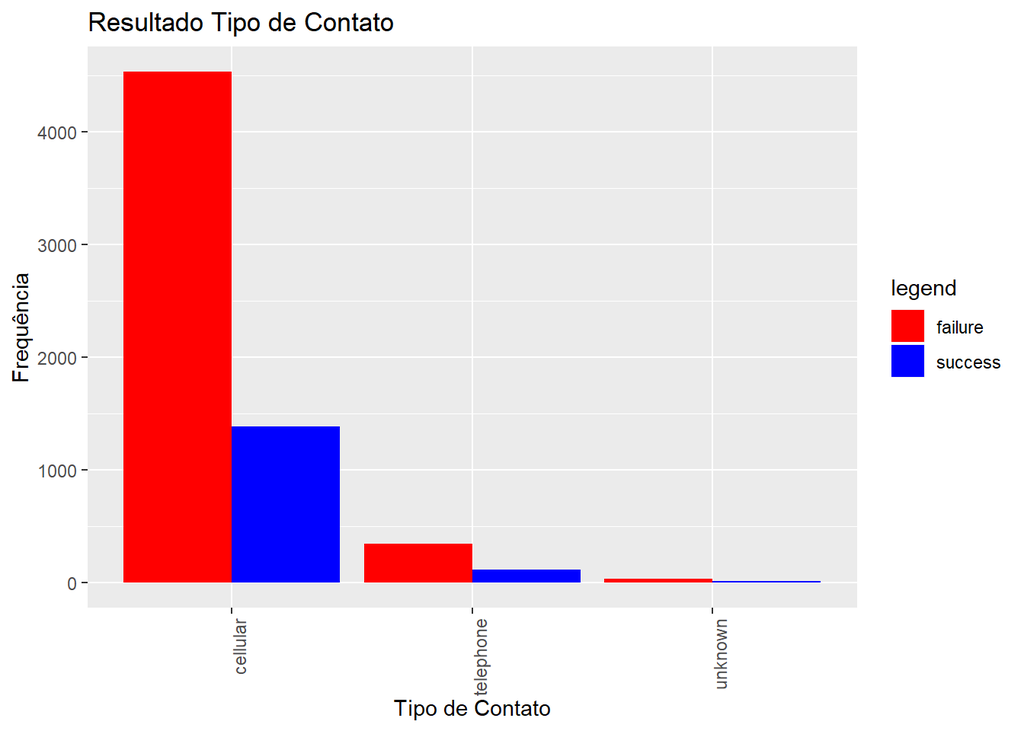

A distribuição dado o tipo de contato também apresenta o mesmo padrão.

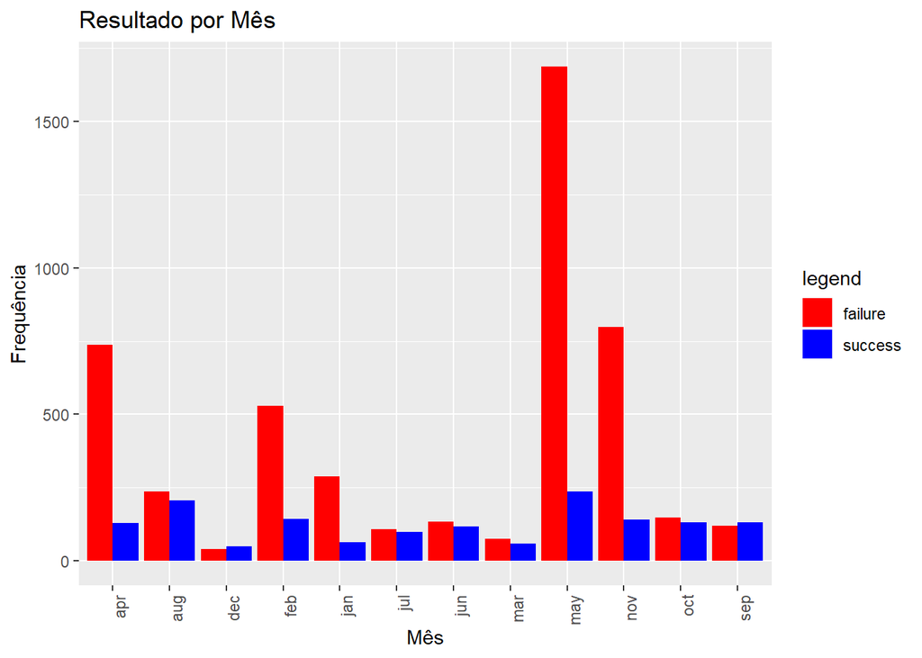

Analisando os meses enquanto critério de sazonalidade podemos afirmar que as campanhas realizadas em agosto, dezembro, julho, junho, março outubro e setembro são as com menor propensão a falha, mas não necessariamente a sucesso, são distribuições equivalentes, mas que não são inclinadas ao fracasso.

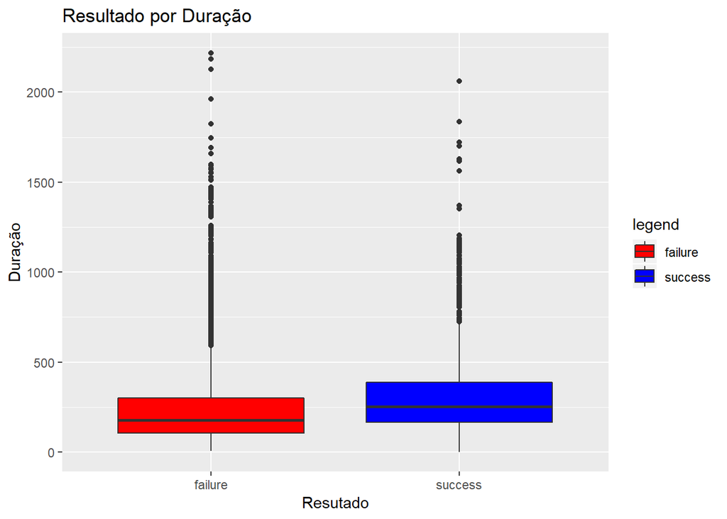

Embora haja muitos outliers, podemos afirmar que há um padrão em relação aos contatos com maior duração. Mas essa correlação não implica causalidade, os contatos com maior duração podem ser consequência do maior interesse dos usuários, por exemplo.

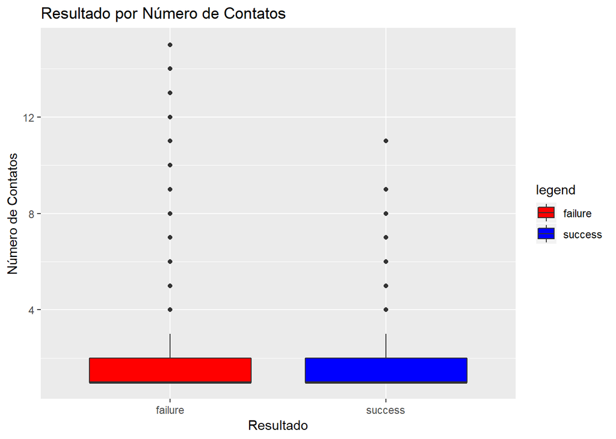

O número de contatos, sozinho, não mostra um padrão significativo que justifique segmentar os resultados a partir dele.

## 2. Conclusão

Sazonalidade é um fator discriminante relevante para a condução das campanhas, as outras variáveis apresentam padrões muito semelhantes, utilizá-las sozinhas como variáveis exôgenas não conduzirá satisfatoriamente os resultados das campanhas.

## 3. Baseando-se nos resultados de adesão desta campanha qual o número médio e o máximo de ligações que você indica para otimizar a adesão? (Conclusão)

A partir da análise anterior, podemos afirmar que o número de ligações não é uma variável que segmenta os dados a ponto de sustentar uma argumentação sólida a respeito da quantidade de ligações.

Mas mesmo não sendo um fator de decisão, podemos indicar o número médio de ligações como 2, e o número máximo como 3.

Os resultados mostram que essas são as quantidades de ligações com maior número de conversões, guardadas seus respectivos outliers, que não devem ser negligenciados, dadas as devidas peculiaridades de cada negociação.

## 4. O resultado da campanha anterior tem relevância na campanha atual?

```
## [1] 0.02519888
```

## 4. Conclusão

Não há correlação entre as variáveis, não podemos afirmar que essa variável seja determinante.

## 5. Qual o fator determinante para que o banco exija um seguro de crédito? (Conclusão)

O fator determinante é se o cliente já possui crédito, ou não. Essa resposta é um padrão de mercado.

## 6. Quais são as características mais proeminentes de um cliente que possua empréstimo imobiliário?

A partir das análises anteriores, duas variáveis proeminentes são a profissão, e o mês da campanha. Número de contatos não é um fator decisivo. Tipo de contato também apresenta um padrão semelhante, não é uma variável que segmenta bem as abordagens de campanha. Duração do contato pode estar influenciada por um confounder, não é uma correlação que pode implicar causalidade

Agora, analisando as outras variaveis.

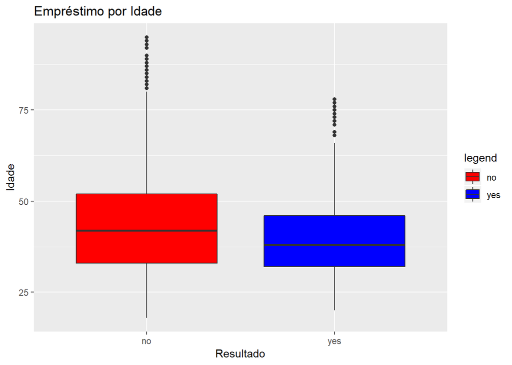

Clientes com menos idade tendem a adquirir mais empréstismos. Mas essa variável também pode estar influenciada por um confounder, clientes com mais idade podem ter mais recursos e não precisar de empréstimos, e clientes com menos idade podem estar começando a fazer seus investimentos, por exemplo.

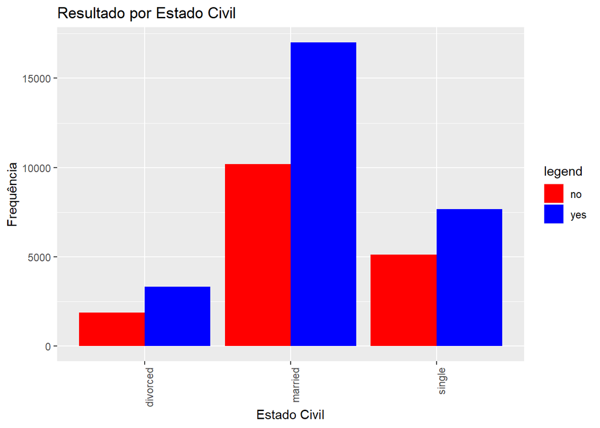

O padrão entre os direntes estados civis se mantém, essa também não é uma variável que segmenta bem os clientes, a título de conduzir novas campanhas.

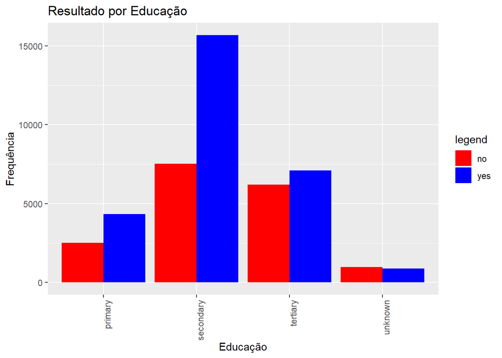

Da mesma forma que a idade, embora essa variável também apresente uma diferença de padrão, também pode estar influenciada por um confounder, então não podemos afirmar com confiança que esse seja um fator de diferenciação preciso, embora possa ser usado.

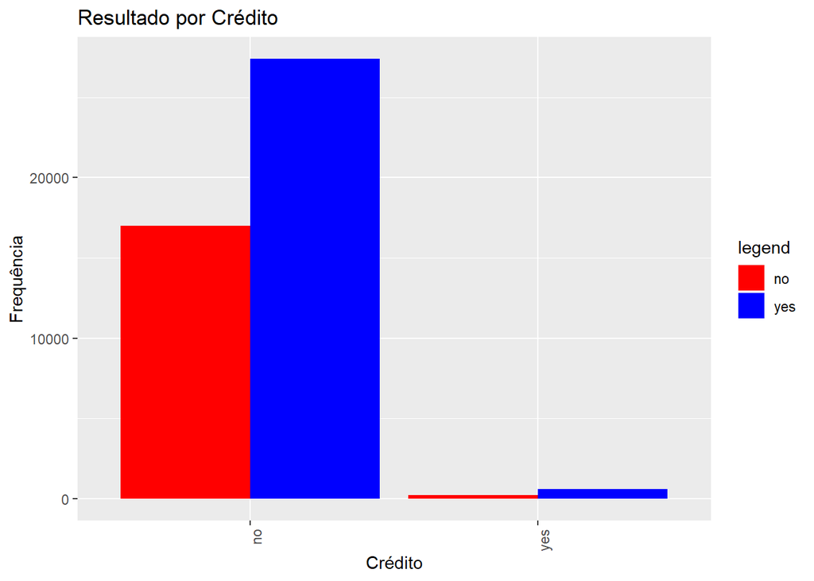

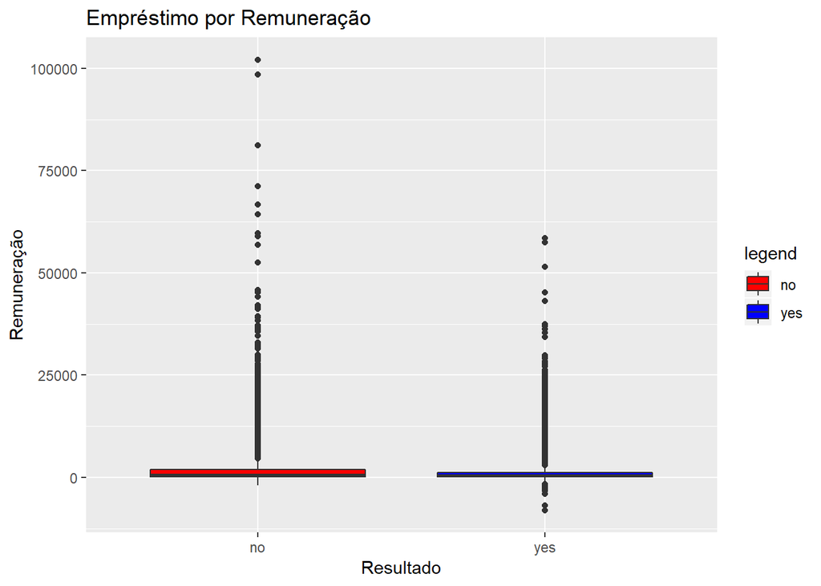

Há muitos outliers em ambos os segmentos de clientes, mas os clientes com uma remuneração menor tendem a adquirr mais empréstismos, o que corrobora as análises anteriores.

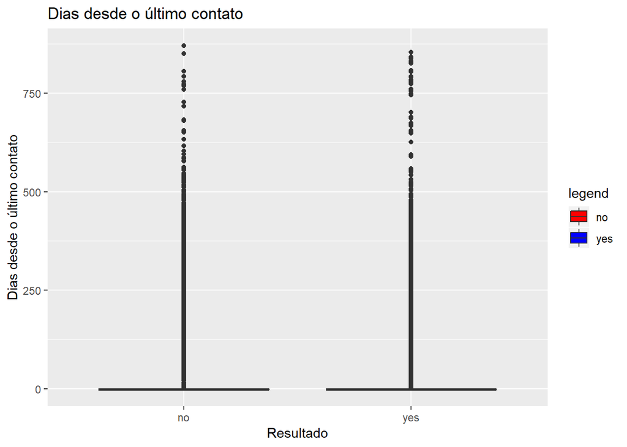

Também há muitos outliers em ambos os segmentos de clientes estratificados a partir dessa variável, analisar o padrão é interessante, mas a diferença é pequena, o que também não nos permite afirmar com confiança que seja uma variável, sozinha, que possa segmentar bem os clientes.

## Fim

Com todas essas análises encontramos padrões muito pertinentes e coerentes para conduzir as próximas campanhas, mais informações tornariam as análises mais ricas, mas com as informações que já possuímos podemos conduzir melhores campanhas, com resultados (muito) mais satisfatórios.